# Regularization

73-423 Forecasting for Economics and Business

## Regularization

- Review of Generalization Problem and ERM
- Structural Risk Minimization Principle
  - Cross Validation
  - Penalized Estimation
- Penalization vs testing/model evaluation

## Risk Minimization

- In statistical learning approach, goal is to produce rule $f\in\mathcal{F}$ with low **risk** for true distribution
  - $R_p(f)=E_p\ell(y_{T+h},f(\mathcal{Y}_{T}))$
- Empirical Risk Minimizer based on minimizing risk for empirical distribution $\widehat{R}(f)=\frac{1}{T-h}\sum_{t=1}^{T-h}\ell(y_{t+h},f(\mathcal{Y}_{t}))$
- The difference between what we want and what we achieve is the *generalization error*
  - $R_p(\widehat{f})=\widehat{R}(\widehat{f})+(R_p(\widehat{f})-\widehat{R}(\widehat{f}))$
  - Data can tell you whether first term is small: minimized by ERM
  - Theory required to ensure second term also small
- Can we do better by being more explicit about generalization error?
  - Sometimes not much: “Fundamental Theorem of Machine Learning” (Mohri et al 2012)
- Under same conditions that ERM has strong performance bound, no method can do “substantially better”
  - In particular, if $\mathcal{F}$ has “low complexity”, excess risk, which is already small, cannot be made much smaller
- Does this mean we may as well always go with ERM?
  - Not really! Especially for small samples $T$ or classes with “high complexity”

## Structural Risk Minimization

- Ideal method would take into account both empirical risk and generalization error
- Impossible to do exactly since generalization error part not known
  - But it can be approximated or bounded!
- Idea: Find a term related to generalization error, called a **penalty** $\mathcal{J}(f)$
- Use a forecasting rule, called a **Structural Risk Minimizer** which minimizes empirical risk plus penalty
  $$\widehat{f}^{SRM}=\underset{f\in\mathcal{F}}{\arg\min}(\frac{1}{T-h}\sum_{t=1}^{T-h}\ell(y_{t+h},f(\mathcal{Y}_{t}))+\mathcal{J}(f))$$
- If penalty exactly equals generalization error, this is *exactly* the oracle estimator
- If penalized risk is a better approximation than the empirical risk, may still outperform ERM
- So, how do we find a good penalty?
  - Many proposed methods
  - Today: A selection of popular penalties and discussion of their properties

## Cross Validation

- We have already seen cross validation as a way to *assess* forecast quality of a forecasting method $\widehat{f}(\mathcal{Y}_{t})$
- Use a forecasting rule *constructed on a training sample* and estimates risk on different **test sample**
  - May do this for many test and training samples, then average the results
  - E.g. Risk estimated from a rolling forecast origin (cf `tsCV`)
    $$\widehat{R}^{tsCV}(\widehat{f})=\frac{1}{T-h}\sum_{t=1}^{T-h}\ell(y_{t+h},\widehat{f}(\mathcal{Y}_{t}))$$
- Many versions exist: test and samples can be blocks, weighted in different ways, etc
- Eg: K-fold CV for ERM over independent data $\{(y_t,z_t)\}_{t=1}^{T}$
  - Split sample into K sets $\mathcal{T}_k$ of size $T/K$
  - For $k=1\ldots K$ estimate $\widehat{f}^{(-k)}=\underset{f\in\mathcal{F}}{\arg\min}\frac{1}{T-T/K}\sum_{t\notin\mathcal{T}_k}\ell(y_t,f(z_t))$
  - $\widehat{R}^{kfoldCV}=\frac{1}{T}\sum_{k=1}^{K}\sum_{t\in\mathcal{T}_k}\ell(y_t,\widehat{f}^{(-k)}(z_t))$
  - For k=T, called “Leave One Out” Cross Validation
- CV reduces bias from overfitting by using different samples for evaluation and testing

## Cross validation over multiple hypothesis classes

- Cross validation can also be used as a way to *choose between* forecasting methods
  - Simply choose the method that minimizes the cross-validation estimate of risk
  - If methods $\widehat{f}$ are just fixed functions, for tsCV this is just ERM again
- Case where CV is useful: when we have *multiple hypothesis classes* of rules $\{\mathcal{F}_c:c\in\mathcal{C}\}$
  - $c$ is a **tuning parameter** affecting some aspect of the procedure, often a measure of complexity
  - Eg for AR(p) classes, $\mathcal{F}_c=\{\beta_0+\sum_{j=1}^{p}\beta_{j}y_{t-j}:\ \beta\in\mathcal{R}^{p+1}\}$, tuning parameter is $p$
  - For each $c\in\mathcal{C}$, run ERM over $\mathcal{F}_c$
    $$\widehat{f}^{c}(\mathcal{Y}_t)=\underset{f\in\mathcal{F}_c}{\arg\min}\frac{1}{t-h}\sum_{s=1}^{t-h}\ell(y_{s+h},f(\mathcal{Y}_{s}))$$
  - Choose $\widehat{c}^{CV}$ by minimizing Cross-Validation risk of $\widehat{f}^{c}()$
    $$\widehat{c}^{CV}=\underset{c\in\mathcal{C}}{\arg\min}\widehat{R}^{CV}(\widehat{f}^{c})$$
  - Forecast using $\widehat{f}^{\widehat{c}^{CV}}$

## Evaluating Cross Validation

- Cross validation over multiple classes not the same as ERM because $\widehat{f}^{c}$ is not a fixed function but depends on the data
- Often, classes are **ordered**: $\mathcal{F}_{c_1}\subset \mathcal{F}_{c_2}$ if $c_1<c_2$
  - Compare small classes of low complexity to big classes of high complexity: More lags, more covariates, etc
- Low complexity classes may have high empirical risk but low error on test set, vice versa for high complexity classes
- Cross validation accounts for these differences: won’t always pick the highest complexity class
- Still have some approximation error, because test set distribution $\neq$ future population distribution
  - Error increases in complexity of $\mathcal{C}$, which is usually small: one or two parmeters
  - Worse when training and test samples are dependent: helped slightly by using tsCV over k-fold
- In general, provides fairly good approximation to generalization error but can be *extremely* costly to compute
  - Solve an optimization problem for each $c\in\mathcal{C}$ for each $t$ in sample
  - Can be hundreds or thousands of times as many computations as a single ERM forecast
- Variants or special cases which are less costly but provide similar or not much worse performance may be preferred

## Information Criteria

- Look for a simple measure $\mathcal{J}()$ of generalization error of rule $f$ using a measure of complexity of class $\mathcal{F}_c$, $\mathcal{J}(\mathcal{F}_c)$
- Note that in ERM, scale of risk doesn’t matter: Applying increasing transform to risk gives same minimizer
- With penalization, effect on minimizer does depend on *relative* scale of criterion and penalty
- Use a *normalized* risk measure, called a *log likelihood* to ensure constant scale
  - Takes form $-2\log(p(\mathcal{Y}_T,f))$ where $p(\mathcal{Y}_T,f)$ is a probability distribution over $\mathcal{Y}_T$
  - Normalized form for square loss is $(T-h)\log(\frac{1}{T-h}\sum_{t=1}^{T-h}(y_{t+h}-f(.))^2)$
  - Cross entropy loss for binary prediction already normalized
- A **penalized log likelihood** adds a penalty $\mathcal{J}$ to normalized risk
- Criterion value of class $c$ is the minimum value of the penalized log likelihood $\underset{f\in\mathcal{F}_c}{\min}(-2\log(p(\mathcal{Y}_T,f)+\mathcal{J}(\mathcal{F}_c))$
- Common penalties based on **number of parameters** p
  - Akaike Information Criterion, **AIC**: $\mathcal{J}(\mathcal{F}_c))=2p$
  - Bayesian Information Criterion, **BIC**: $\mathcal{J}(\mathcal{F}_c))=2p\log(T-h)$ (also called Schwarz Criterion, **SC**)
- Choose a rule which minimizes the penalized log likelihood $\widehat{f}^{\mathcal{J}}=\underset{f\in\mathcal{F}_c,c\in\mathcal{C}}{\arg\min}(-2\log(p(\mathcal{Y}_T,f)+\mathcal{J}(\mathcal{F}_c))$

## Evaluation and implementation

- AIC and BIC designed to pick a rule with low risk
- BIC has slightly larger penalty: downgrades more complex models more
  - Under some very strong conditions, AIC “close to” true risk, at least when T is large
  - BIC instead designed to pick “true model” when T is large
- For forecasting usually care about formaer rather than latter goal
  - For this reason, Hyndman & Athanasopolous text recommends AIC
- But be cautious: result requires large samples, and in small samples AIC can be bad measure of risk
  - For this reason, Diebold text recommends BIC, as slightly larger penalty accounts for chance of overfitting from misestimation of risk
- Both estimates usually provide worse measure of risk than cross validation
  - Sometimes faster: $\approx T$ times fewer optimizations
    - Exception is linear models, where known formula simplifies CV calculations
- Automatically reported with `Arima`, `VAR`, `ets`, etc, or ex post by `CV`
  - AIC also part of `auto.arima`, to choose between orders of AR
  - `VARselect` computes AIC/BIC for VAR over loss $\log\det(\sum_{t=1}^{T-h}(y_{t+h}-\widehat{y}_{t})(y_{t+h}-\widehat{y}_{t})^\prime)$

## Parameter size based penalties

- Penalization based on *number* of parameters require solving model for each parameter set $c\in\mathcal{C}$
  - Fine if only a small number: once per lag order of AR/VAR up to max lag, hard if sets $\mathcal{F}_c$ are every possible subset of p regressors: $2^p$ regressions
- Works if best predictions come from ignoring all but a subset of predictors, and leaving rest unrestricted
- Alternative: allow all predictors to matter, but reduce total **size** of parameters by penalizing their **norm**
- Linear hypothesis classes $\mathcal{F}=\{\beta_0+\sum_{j=1}^m\beta_j z_j:\ \beta\in\mathbb{R}^{m+1}\}$, penalty is $\lambda\Vert\beta\Vert^p_p$
- Norm $\Vert\beta\Vert_p$ is a measure of “size” of coefficients, e.g.
  - L1 (LASSO) Penalty $\Vert\beta\Vert^1_1=\sum_{j=0}^d\|\beta_j\|$
  - L2 (Ridge) Penalty $\Vert\beta\Vert^2_2=\sum_{j=0}^d(\beta_j)^2$
  - Mixed L1/L2 (Elastic Net) Penalty $\Vert\beta\Vert_{1/2,a}=a\Vert\beta\Vert^1_1+(1-a)\Vert\beta\Vert^2_2$ for $a\in[0,1]$
- $\lambda\geq 0$ decides size of penalty term
  - Large value means strong restrictions: coefficients shrink a lot and class much simpler
  - Small value allows more complexity, at cost of greater overfitting risk. 0 means no restrictions: estimator is just ERM
- Penalized estimator solves $\widehat{f}^\lambda=\underset{f\in\mathcal{F}}{\min}(\frac{1}{T-h}\sum_{t=1}^{T-h}\ell(y_{t+h},f(\mathcal{Y}_t))+\lambda\Vert\beta\Vert_p^p)$

## Evaluation and Implementation

- Norm penalized estimators address overfitting by preventing large fluctuations in values of parameters
- Type of norm controls which kinds of fluctuations are more or less restricted
- L2 penalty more strongly affected by very large values, less by small values
  - All values partially shrink
- L1 penalty equally strongly affected by small and large values
  - Allows some larger coefficients, but shrinks a lot smaller ones, often to exactly 0: **sparsity**
  - Acts like penalties on # of parameters, but non-0 coefficients also slightly shrunk
- Elastic net in between, by amount controlled by $a$: small terms go to 0, but big terms also shrunk
- For a fixed penalty size $\lambda$ computation is easy: one instead of many optimizations
- Scale problem: how to choose $\lambda$?
  - Typically, find $\widehat{f}^\lambda$ for many $\lambda$ and select $\widehat{\lambda}^{CV}$ by cross validation
  - Efficient LARS algorithm makes computation for all $\lambda$ fast in linear model
- Implemented for linear hypotheses and square loss, cross-entropy, multivariate square loss, etc in `glmnet`
  - `cv.glmnet` implements cross validation parameter selection, but not time series version

## What kinds of model classes?

- Penalizing size of parameters can substitute for using smaller number of parameters
- Can include more predictors for same level of generalization error if penalized
  - Can use many predictors, or nonlinear functions of predictors: polynomials, splines, etc
  - Benefit is better ability to predict and get close to oracle predictor
  - Cost is that values of parameters get distorted
- How complicated can model class be?
  - Depends on number of possible relevant predictors and how big complicated a model within that class
- LASSO can handle more parameters than data points, if most are (close to) 0
  - Up to exponentially many if very sparse and large $\lambda$ chosen
- Ridge can handle arbitrary number of predictors
  - But effects of each become progressively more muted
- In practice, use LASSO with many weakly related predictors, of which only some might matter
- Use ridge with many, possibly related predictors, each of which contributes a little bit to the forecast
  - Often believable for lags, so common to use in (V)AR estimates

## Function based penalties

- Rather than penalizing parameters of predictor $f()$, you can penalize $f$ directly
- Penalized estimator solves, for $\lambda\Vert f\Vert$ some norm on $f$,
  - $\widehat{f}^\lambda=\underset{f\in\mathcal{F}}{\min}(\frac{1}{T-h}\sum_{t=1}^{T-h}\ell(y_{t+h},f(\mathcal{Y}_t))+\lambda\Vert f\Vert)$
- For classes $\mathcal{F}$ defined by parameters, like linear hypothesis class, little essential difference
  - (Usually) equivalent to some penalty on parameters
- But if class $\mathcal{F}$ isn’t dependent on a (finite) set of parameters, eg $\mathcal{F}=\{\text{all functions of Z}\}$, can be very different
- Most prominent example: mean squared second derivative penalty $\Vert f\Vert=\int f^{\prime\prime}(z)^2dz$
  - Penalizes “wiggliness” regardless of particular shape: minimal for straight line
- Amazing fact (cf Wahba 1990): penalized minimizer over class of all functions has known, computable form
  - Called a “Smoothing Spline”: piecewise cubic polynomial between data points
  - Equivalent to ridge penalty over (T-dimensional) class of piecewise cubic polynomials
- Implemented as `smooth.spline` as well as in specialized functions in libraries `gam` or `mgcv`
- Choose $\lambda$ by CV again: fast algorithm known for non-time series case

## Smoothing Splines: GDP growth from Lagged GDP growth

```r
library(fpp2) #Forecasting
library(glmnet) #Lasso and Ridge
library(vars) #Vector Autoregressions
library(fredr) #Access FRED Data

##Obtain and transform NIPA Data (cf Lecture 08)

fredr_set_key("8782f247febb41f291821950cf9118b6") #Key I obtained for this class

#US GDP components
GDP<-fredr(series_id = "GDP",
           observation_start = as.Date("1947-01-01")) #Gross Domestic Product

#US GDP components from NIPA tables (cf http://www.bea.gov/national/pdf/nipaguid.pdf)
PCEC<-fredr(series_id = "PCEC",
            observation_start = as.Date("1947-01-01")) #Personal consumption expenditures
FPI<-fredr(series_id = "FPI",
           observation_start = as.Date("1947-01-01")) #Fixed Private Investment
CBI<-fredr(series_id = "CBI",
           observation_start = as.Date("1947-01-01")) #Change in Private Inventories
NETEXP<-fredr(series_id = "NETEXP",
              observation_start = as.Date("1947-01-01")) #Net Exports of Goods and Services
GCE<-fredr(series_id = "GCE",
           observation_start = as.Date("1947-01-01")) #Government Consumption Expenditures and Gross Investment

#Format the series as quarterly time series objects, starting at the first date
gdp<-ts(GDP$value,frequency = 4,start=c(1947,1),names="Gross Domestic Product")
pcec<-ts(PCEC$value,frequency = 4,start=c(1947,1),names="Consumption")
fpi<-ts(FPI$value,frequency = 4,start=c(1947,1),names="Fixed Investment")
cbi<-ts(CBI$value,frequency = 4,start=c(1947,1),names="Inventory Growth")
invest<-fpi+cbi #Private Investment
netexp<-ts(NETEXP$value,frequency = 4,start=c(1947,1),names="Net Exports")
gce<-ts(GCE$value,frequency = 4,start=c(1947,1),names="Government Spending")

#Convert to log differences to ensure stationarity and collect in frame
NIPAdata<-ts(data.frame(diff(log(gdp)),diff(log(pcec)),diff(log(invest)),diff(log(gce))),frequency = 4,start=c(1947,2))

# Construct lags

l1NIPA<-window(stats::lag(NIPAdata,-1),start=c(1949,2),end=c(2018,3))
l2NIPA<-window(stats::lag(NIPAdata,-2),start=c(1949,2),end=c(2018,3))
l3NIPA<-window(stats::lag(NIPAdata,-3),start=c(1949,2),end=c(2018,3))
l4NIPA<-window(stats::lag(NIPAdata,-4),start=c(1949,2),end=c(2018,3))
l5NIPA<-window(stats::lag(NIPAdata,-5),start=c(1949,2),end=c(2018,3))
l6NIPA<-window(stats::lag(NIPAdata,-6),start=c(1949,2),end=c(2018,3))
l7NIPA<-window(stats::lag(NIPAdata,-7),start=c(1949,2),end=c(2018,3))
l8NIPA<-window(stats::lag(NIPAdata,-8),start=c(1949,2),end=c(2018,3))

#convert to matrices
xvarsdf<-data.frame(l1NIPA,l2NIPA,l3NIPA,l4NIPA,l5NIPA,l6NIPA,l7NIPA,l8NIPA)
xvars<-as.matrix(xvarsdf)
NIPAwindow<-matrix(window(NIPAdata,start=c(1949,2),end=c(2018,3)),length(l1NIPA[,1]),4)

#Spline models, yeah?
library(gam) #loads smoothing spline package
lagDlogGDP<-xvars[,1]
DlogGDP<-NIPAwindow[,1]
#Smoothing spline Regression of GDP on lagged GDP
# Default behavior fits penalty parameter by generalized Cross Validation
```

```r
# Predict GDP growth using smoothing spline in lagged GDP growth
gdp.spl<-smooth.spline(lagDlogGDP,DlogGDP)
splinepredictions<-predict(gdp.spl)
```

- $\lambda=$ 0.573289 chosen by (non-time series) cross validation gives almost exactly linear fit

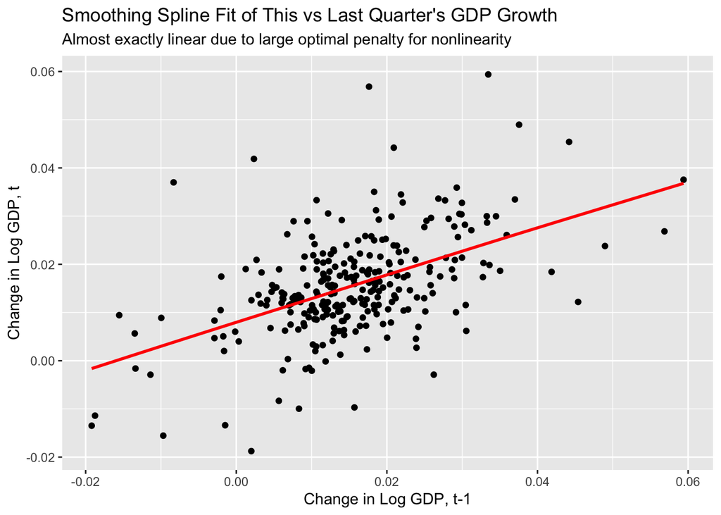

```r
#Build Plot
gdpdata<-data.frame(xvars[,1],NIPAwindow[,1],splinepredictions$x,splinepredictions$y)
colnames(gdpdata)<-c("LDlGDP","DlGDP","xspline","yspline")

ggplot(gdpdata,aes(x=LDlGDP,y=DlGDP))+geom_point()+
  geom_line(aes(x=xspline,y=yspline),color="red",size=1)+
  ggtitle("Smoothing Spline Fit of This vs Last Quarter's GDP Growth",
          subtitle="Almost exactly linear due to large optimal penalty for nonlinearity")+
  xlab("Change in Log GDP, t-1")+ylab("Change in Log GDP, t")
```

```r
# An alternate approach which uses "gam" command to fit spline
# Advantage is that it's built in to ggplot
# Disadvantage is that it uses only default options, so not customizable
# In this case, results are exactly the same

# ggplot(gdpdata,aes(x=LDlGDP,y=DlGDP))+geom_point()+
#   ggtitle("Spline and OLS Fit of This vs  Last Quarter's GDP Growth",
#           subtitle="There are two lines which exactly overlap")+
#   xlab("Change in Log GDP, t-1")+ylab("Change in Log GDP, t")+
#   geom_smooth(method=gam,se=FALSE,color="blue")+
#   geom_smooth(method=lm,se=FALSE,color="red")
```

## Exotic penalties

- Example penalties I mentioned are just most common ones
- New and different penalties can be used to emphasize different features of the prediction or type of data used
  - Thousands in statistics/ML literature, and new ones every day
- Parameter-based penalties can emphasize different sets of parameters or features of size or shape
- Function based penalties can look at fine or large scale features, or multiple variables
  - Cases which allow finite computable solution are called (reproducing) **kernel** methods
- Shared principle: want to trade off flexible form to match patterns in observed data against size and complexity of class
  - Different prediction tasks will call for different shapes, sizes of data, so specialized penalties can help

## Penalties versus Bounds

- Alternately, can just run ERM over predictor class $\mathcal{F}$ with restriction that $\Vert f \Vert \leq c$ for some c
  - $\widehat{f}^{ERM,c}=\underset{f\in\mathcal{F}, \Vert f \Vert\leq c}{\min}(\frac{1}{T-h}\sum_{t=1}^{T-h}\ell(y_{t+h},f(\mathcal{Y}_t)))$
- E.g. only look at functions with norm of predictors bounded $\mathcal{F}_c=\{\beta_0+\sum_{j=1}^d\beta_jz_j:\ \beta\in\mathbb{R}^{d+1}, \Vert\beta\Vert_p\leq c\}$
- Can choose $c$ by cross-validation, just like with penalty
- Claim: ERM over class with bound imposed is numerically identical to some penalized empirical risk minimizer
- More formally, for any $c>0$, there is some $\widehat{\lambda}(c)$ such that
  - $\widehat{f}^{ERM,c}=\underset{f\in\mathcal{F}}{\arg\min}(\frac{1}{T-h}\sum_{t=1}^{T-h}\ell(y_{t+h},f(\mathcal{Y}_t))+\widehat{\lambda}(c)\Vert f\Vert)$
- This is application of Lagrange multiplier theorem from constrained optimization
- Slight difference is that $\widehat{\lambda}(c)$ may depend on the data, whereas it is fixed in penalized case
  - Though since $c$ and $\lambda$ usually chosen based on data anyway, even this usually not a difference
- Thus, penalization inherits properties of ERM, but with a new, restricted class of predictors
  - Explains variety of possible penalties: just different functions of the data

## Regularization for GDP Forecasting

```r
library(dplyr) #Data manipulation
library(knitr) #Use knitr to make tables
library(kableExtra) #Extra options for tables
library(tibble) #More data manipulation
#Calculate information criteria
IC<-VARselect(NIPAdata,lag.max=8)

# Fit Optimal VARs by AIC, BIC
AICVAR<-VAR(NIPAdata,p=IC$selection[1])
BICVAR<-VAR(NIPAdata,p=IC$selection[3])

#Construct 1 period ahead foecasts
AICpred<-forecast(AICVAR,h=1)$forecast
BICpred<-forecast(BICVAR,h=1)$forecast

#Extract point forecasts
AICfcsts<-select(data.frame(AICpred),ends_with("Forecast"))
BICfcsts<-select(data.frame(BICpred),ends_with("Forecast"))


#Fit LASSO VAR in all variables up to 8 lags
lassovar<-glmnet(xvars,NIPAwindow,family="mgaussian")

#Show range of lambda values from unpenalized to where all variables gone
#lassovar$lambda

#Show coefficients for large value of lambda (heavy penalization, most coefs gone)
#coef(lassovar,s=0.02)

#Show coefficients for intermediate value of lambda (medium penalization, some coefs gone)
#coef(lassovar,s=0.008)

#Show coefficients for small value of lambda (little penalization, most coefs remain)
#coef(lassovar,s=0.001)

## Fit LASSO VAR with 10-fold cross-validation
lassovarCV<-cv.glmnet(xvars,NIPAwindow,family="mgaussian")

#Lambda giving minimum 10-fold Cross Validation Error
CVlambda<-lassovarCV$lambda.min

#Baroque construction to take last period and format it for predict command
#Somehow need 2 rows in prediction value or it throws a fit
#Presumably because matrix coerced to vector and then it thinks it can't multiply anymore
newX<-t(as.matrix(data.frame(as.vector(t(NIPAwindow[270:277,])), as.vector(t(NIPAwindow[271:278,])))))

#Predict 2018Q3 series
cvlassopredictions<-window(ts(predict(lassovarCV,newx = newX)[,,1],start=c(2018,3),frequency=4),start=c(2018,4))

#Fit L2 Penalized VAR in all variables up to 8 lags
ridgevar<-glmnet(xvars,NIPAwindow,alpha=0,family="mgaussian")

#Show range of lambda values from unpenalized to where all variables gone
#ridgevar$lambda

#Show coefficients for large value of lambda (heavy penalization, coefs shrink a lot)
#coef(ridgevar,s=10)

#Show coefficients for intermediate value of lambda (medium penalization, coefs shrink a little)
#coef(ridgevar,s=1)

#Show coefficients for small value of lambda (little penalization, coefs close to OLS values)
#coef(ridgevar,s=0.01)

## Fit Ridge VAR with 10-fold cross-validation
ridgevarCV<-cv.glmnet(xvars,NIPAwindow,alpha=0,family="mgaussian")

#Lambda giving minimum 10-fold Cross Validation Error
CVlambda2<-ridgevarCV$lambda.min

#Predict 2018Q3 series
cvridgepredictions<-window(ts(predict(ridgevarCV,newx = newX)[,,1],start=c(2018,3),frequency=4),start=c(2018,4))

# #Plot Data Series
# autoplot(window(NIPAdata,start=c(2012,4)))+
#   autolayer(cvlassopredictions)+
#   autolayer(cvridgepredictions)

#  autolayer(AICpred$diff.log.gdp..$mean)+
 # autolayer(BICpred$diff.log.gdp..$mean)
```

```r
#Collect 2018Q4 Forecasts into a data frame
var1table<-data.frame(
  t(cvridgepredictions),
  t(cvlassopredictions),
  t(AICfcsts),
  t(BICfcsts)
)
rownames(var1table)<-c("GDP","Consumption","Investment","Government")
#Make Table of Estimated Coefficients
kable(var1table,
  col.names=c("Ridge","LASSO","AIC","BIC"),
  caption="2018Q4 Forecasts from Different Methods") %>%
  kable_styling(bootstrap_options = "striped", font_size = 16)
```

2018Q4 Forecasts from Different Methods

|  | Ridge | LASSO | AIC | BIC |
| --- | --- | --- | --- | --- |
| GDP | 0.0135764 | 0.0136399 | 0.0114672 | 0.0146535 |
| Consumption | 0.0145109 | 0.0150744 | 0.0114084 | 0.0137662 |
| Investment | 0.0141675 | 0.0096423 | 0.0147074 | 0.0200288 |
| Government | 0.0112001 | 0.0129239 | 0.0109967 | 0.0142961 |

## Ridge Coefficients

```r
#Make Coefficient Table
zzz<-data.frame(as.matrix(coef(ridgevarCV)$y1),
                as.matrix(coef(ridgevarCV)$y2),
                as.matrix(coef(ridgevarCV)$y3),
                as.matrix(coef(ridgevarCV)$y4))


rownames(zzz)<-rownames(data.frame(as.matrix(coef(ridgevarCV)$y1)))
zzz %>%
mutate_all(function(x) {
    cell_spec(x, bold = T,
              color = spec_color(x))
  }) %>%
  kable(escape=F,
  col.names=c("GDP","C","I","G"),
  caption="Coefficients in Ridge Regression") %>%
  kable_styling(bootstrap_options = "striped", font_size=10)
```

Coefficients in Ridge Regression

| GDP | C | I | G |
| --- | --- | --- | --- |
| 0.00786403925303112 | 0.00788037586534336 | 0.0148332433942633 | 0.00238697200569118 |
| 0.0865957812778728 | 0.0551696965390487 | 0.244556969538606 | 0.0942090494910388 |
| 0.109959994411296 | 0.0140186300705327 | 0.652435086528036 | 0.0271147781051111 |
| 0.0123857804601417 | 0.0146716727038759 | 0.0263673253409791 | 0.00451694512000495 |
| 0.0106451182691282 | -0.000384426841756296 | -0.10326596491934 | 0.129021260675576 |
| 0.0621757521642605 | 0.0507324374153117 | 0.0591602476118126 | 0.0915652117483974 |
| 0.0685132890145487 | 0.0872907695940012 | 0.0201799922326903 | 0.0757765565334758 |
| 0.00980081641152812 | 0.00612229583374719 | 0.0264123256900968 | 0.00341895148384484 |
| -0.00091364858455345 | -0.0183671961947785 | -0.0452636148290377 | 0.0728980049798622 |
| 0.00222284364167427 | 0.000153134673311346 | -0.128645457778679 | 0.0690242604269709 |
| 0.0281940450636521 | 0.0281374237646931 | -0.0171630376438789 | 0.0241099553055666 |
| -0.000742106997763265 | -0.00393726953375673 | -0.0148823646684543 | 0.00991134660015443 |
| -0.0117103950975583 | 0.00390704975726952 | -0.124060760551806 | 0.042365378160212 |
| 0.00466436718790951 | 0.0198055138385727 | -0.11583119132355 | 0.0696018152897233 |
| 0.0261427471133706 | 0.0118711044130767 | 0.0680154676403516 | 0.0163018495414982 |
| -0.00167161870530863 | 0.00573285857652937 | -0.0541920520539569 | 0.0168684912766791 |
| -0.00858261369081641 | -0.000107206981960806 | -0.0348551138082085 | 0.0112101644913383 |
| -0.0232727042683797 | -0.00429662421540572 | -0.167820490545611 | 0.0172672049947349 |
| 0.00391586808909369 | 0.0427292362405572 | -0.200572063884623 | 0.0349239157634509 |
| -0.00664742359679361 | -0.0104016875491473 | -0.0190333240075376 | 0.00595507032903712 |
| 0.00538793204213564 | 0.0128902984939667 | 0.02284614151604 | -0.0114685479470082 |
| 0.00544131900827601 | 0.0144369960515328 | -0.0303801828996868 | -0.00363175835548809 |
| 0.0164253253291509 | 0.018465576565109 | 0.0345073433829858 | -0.0126745355744008 |
| -0.00190203067553394 | 5.72598991601035e-05 | -0.0190653286699528 | 0.00404537508886109 |
| 0.0197841229410908 | 0.0160085909139529 | 0.0842755170708496 | 0.00830309472111045 |
| 0.0120147540294824 | 0.0243376461687585 | -0.0165184864873954 | 0.00719547800775078 |
| 0.040296252839528 | 0.0596415983729323 | 0.02774714220003 | 0.0114532053990684 |
| -0.0024274892654373 | -0.0029465709365635 | 0.00107392698826947 | -0.00148227405584982 |
| 0.0143235423939472 | 0.0095686832241577 | 0.0646786514144629 | 0.00189470282102794 |
| 0.00654277888835529 | 0.0260428281389034 | -0.0835351764832077 | 0.00556255654741 |
| 0.00740736376961867 | 0.0193445802289786 | -0.0299715588564189 | 0.0107470604622051 |
| 0.00244101702686358 | 0.00315971586949353 | 0.00301646433765767 | -0.00377054987395623 |
| -0.0048771079424408 | -0.000351952561224234 | -0.0574670100128757 | 0.010569599656017 |

## LASSO Coefficients

```r
#Make Coefficient Table
zzz<-data.frame(as.matrix(coef(lassovarCV)$y1),
                as.matrix(coef(lassovarCV)$y2),
                as.matrix(coef(lassovarCV)$y3),
                as.matrix(coef(lassovarCV)$y4))

rownames(zzz)<-rownames(data.frame(as.matrix(coef(lassovarCV)$y1)))
zzz %>%
mutate_all(function(x) {
    cell_spec(x, bold = T,
              color = if_else(x!=0,"red","black"))
  }) %>%
  kable(escape=F,
  col.names=c("GDP","C","I","G"),
  caption="Coefficients in LASSO Regression") %>%
  kable_styling(bootstrap_options = "striped", font_size=10)
```

Coefficients in LASSO Regression

| GDP | C | I | G |
| --- | --- | --- | --- |
| 0.0100302004924729 | 0.0129798197145501 | 0.00168310308800569 | 0.00756634626175604 |
| 0 | 0 | 0 | 0 |
| 0.349959458943998 | 0.130476409727349 | 1.56554483539441 | 0.175646554336095 |
| 0 | 0 | 0 | 0 |
| 0.0189475717511366 | 0.00825380129907898 | -0.200786258486333 | 0.211575231022215 |
| 0 | 0 | 0 | 0 |
| 0 | 0 | 0 | 0 |
| 0 | 0 | 0 | 0 |
| 0 | 0 | 0 | 0 |
| 0.00317825905700754 | 0.00415960881665426 | -0.0480514970684653 | 0.026735352282484 |
| 0 | 0 | 0 | 0 |
| 0 | 0 | 0 | 0 |
| -0.000579291079324646 | 0.00107644280868163 | -0.0116456790667297 | 0.00480000882876038 |
| 0 | 0 | 0 | 0 |
| 0 | 0 | 0 | 0 |
| 0.000140488939523953 | 0.00533714789277771 | -0.0489610167268404 | 0.0198565317923048 |
| 0 | 0 | 0 | 0 |
| -0.0248114736550768 | 0.00358810219897533 | -0.246221267350789 | 0.0430723482194091 |
| 0.00499345322235313 | 0.0241926374897687 | -0.102657716554927 | 0.0268686037123245 |
| 0 | 0 | 0 | 0 |
| 0 | 0 | 0 | 0 |
| 0 | 0 | 0 | 0 |
| 0 | 0 | 0 | 0 |
| 0 | 0 | 0 | 0 |
| 0 | 0 | 0 | 0 |
| 0 | 0 | 0 | 0 |
| 0 | 0 | 0 | 0 |
| 0 | 0 | 0 | 0 |
| 0 | 0 | 0 | 0 |
| 0 | 0 | 0 | 0 |
| 0 | 0 | 0 | 0 |
| 0 | 0 | 0 | 0 |
| 0 | 0 | 0 | 0 |

## AIC Coefficients

```r
#Make Coefficient Table
zzz<-data.frame(AICVAR$varresult$diff.log.gdp..$coefficients,
                AICVAR$varresult$diff.log.pcec..$coefficients,
                AICVAR$varresult$diff.log.invest..$coefficients,
                AICVAR$varresult$diff.log.gce..$coefficients)

rownames(zzz)<-rownames(data.frame(AICVAR$varresult$diff.log.gdp..$coefficients))
zzz %>%
mutate_all(function(x) {
    cell_spec(x, bold = T,
              color = if_else(x!=0,"red","black"))
  }) %>%
  kable(escape=F,
  col.names=c("GDP","C","I","G"),
  caption="Coefficients in AIC Regression") %>%
  kable_styling(bootstrap_options = "striped", font_size=10)
```

Coefficients in AIC Regression

| GDP | C | I | G |
| --- | --- | --- | --- |
| 0.0142423802331418 | 0.335379954233719 | -1.66567424374834 | -0.0458342811491882 |
| 0.412581978510042 | -0.145870908410638 | 3.63202838343984 | 0.143896666113282 |
| 0.0274378660517431 | -0.0156497514807466 | 0.287226644977188 | 0.042002491417178 |
| 0.0643892203157539 | -0.0233881252807245 | 0.0174160286406101 | 0.472850970012959 |
| 0.229659888723582 | 0.269399415045273 | -0.143262388462611 | 0.351609194937956 |
| 0.0702970032085799 | 0.173522014804767 | -0.0975467195269845 | 0.0158414129010053 |
| -0.0171415190305722 | -0.0323539077927016 | 0.0475055185498714 | -0.0412019143794856 |
| -0.0420896176116723 | -0.158539060486606 | 0.177660920656683 | 0.0443322148452024 |
| -0.0530503159805621 | -0.105453086053541 | -0.417634348755004 | 0.0518474932711676 |
| 0.0417016846902634 | 0.159668297181366 | -0.283642111390404 | -0.128775449751194 |
| -0.0209115301435752 | -0.0200053835083251 | -0.0549504273458671 | 0.030162245635792 |
| -0.0244971810971676 | 0.0310810988172909 | -0.186714858168813 | 0.072437242832677 |
| 0.194846774896595 | -0.0456390218211937 | 1.69673325899881 | 0.291405949868535 |
| 0.0438158991226434 | 0.118599212590941 | -0.318354688568522 | -0.266886732092782 |
| -0.0436234814162472 | 0.0124385525781957 | -0.371750797774807 | 0.00287302373823534 |
| -0.0939728362880406 | 0.0256517076994152 | -0.641177916328012 | -0.0349723904845601 |
| -0.375654283804274 | 0.0714799076733018 | -1.78345775966185 | -0.427496739634625 |
| 0.214299611678092 | 0.0808915731483531 | 0.421133953050024 | 0.275045376137453 |
| 0.0179499285089324 | -0.0456210321684576 | 0.139224678770525 | 0.055414493021536 |
| 0.115882613339792 | 0.0566722429832534 | 0.423603489217224 | 0.0137362064712486 |
| 0.00327979811668631 | 0.00411587418405196 | 0.00146212088776681 | 0.00125004595756258 |

## BIC Coefficients

```r
#Make Coefficient Table
zzz<-data.frame(BICVAR$varresult$diff.log.gdp..$coefficients,
                BICVAR$varresult$diff.log.pcec..$coefficients,
                BICVAR$varresult$diff.log.invest..$coefficients,
                BICVAR$varresult$diff.log.gce..$coefficients)

rownames(zzz)<-rownames(data.frame(BICVAR$varresult$diff.log.gdp..$coefficients))
zzz %>%
mutate_all(function(x) {
    cell_spec(x, bold = T,
              color = if_else(x!=0,"red","black"))
  }) %>%
  kable(escape=F,
  col.names=c("GDP","C","I","G"),
  caption="Coefficients in BIC Regression") %>%
  kable_styling(bootstrap_options = "striped", font_size=10)
```

Coefficients in BIC Regression

| GDP | C | I | G |
| --- | --- | --- | --- |
| 0.121952811213594 | 0.443954168101468 | -1.96535758395511 | 0.127651524807346 |
| 0.407141812161502 | -0.1140622757727 | 3.58351024967781 | 0.00635501513565612 |
| 0.0354252888148711 | -0.00443586493533627 | 0.360026691647868 | 0.0435240022800619 |
| 0.00925600061424106 | -0.0503410167955548 | -0.389919533571099 | 0.598248368556429 |
| 0.00650643901357845 | 0.0114194256502141 | -0.00914962148014678 | 0.0035845689397845 |

## Evaluating Autoregressive Forecasts

- Forecast residuals from *optimal* forecast $\widehat{e}_{t+1}=y_{t+1}-\widehat{y}_{t+1}$ are white noise in autoregressive model
- This is in fact true when forecast rule is Bayes predictor in square loss for any stationary distribution
  - Holds for VARs, regression, etc
- So if you are using a rule which is approximately the Bayes rule, residuals should be close to white noise
  - ACF of $\widehat{e}_{t+1}$ should be close to 0 everywhere
  - Use `checkresiduals` to inspect and compare various measures of distance
- Usually little reason to believe chosen family contains Bayes forecast rule
  - May not be exactly linear, or may depend on information further back than number of lags used
  - Or even if it did that approximation is close enough that all properties of Bayes forecast hold for approximate rule
- These two issues are in conflict
  - Can always increase complexity of hypothesis class to try to get closer to Bayes forecaster
  - But doing so can worsen overfitting, making rule actually chosen further away
- Residual checks measure closeness of fit, but are unrelated to degree of overfitting
  - Generally **not** a reliable tool for finding a good forecast, as opposed to checking ex post
  - Prefer measures which account for all types of error

## Application to GDP Series in BIC VAR Prediction

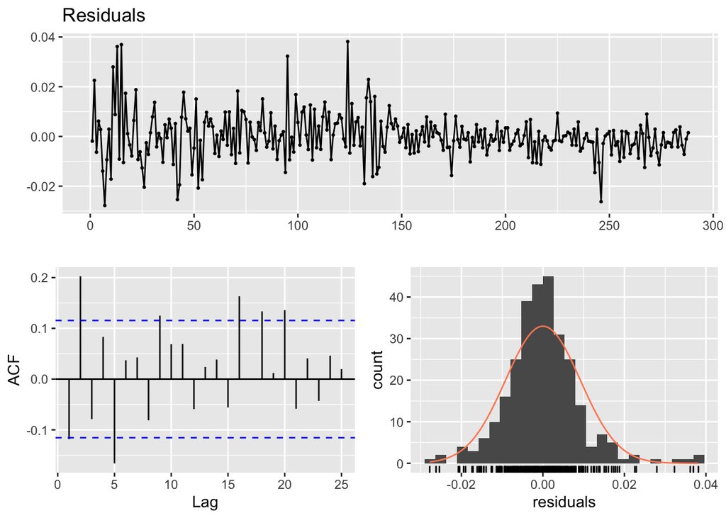

```
##
##  Breusch-Godfrey test for serial correlation of order up to 10
##
## data:  Residuals
## LM test = 36.01, df = 10, p-value = 8.386e-05
```

```r
checkresiduals(BICVAR$varresult$diff.log.gdp..) #GDP Growth forecast residual diagnostic
```

- Patterns in residual plot and ACF, and formal test of white noise, suggest VAR(1) is not super close to white noise
  - Suggests patterns in data may differ somewhat from VAR(1) model: in-sample fit could be improved
  - To decide whether this or another forecast should be used, should compare loss measures

## Conclusions

- ERM does well for choosing within a simple hypothesis classes
- Minimizing penalized criterion is a sensible way to improve accounting for overfitting
  - Based on number (AIC/BIC) or size (L1/L2) of parameters or functions
- When choosing between multiple procedures, including ERM over multiple classes, can use measure of risk for each
  - Cross-validation
- Penalization acts like restricting size of parameter class
  - Can choose penalty by cross-validating
- Goal of regularization is to trade off in-sample and out-of-sample fit
  - Other tools exist for finding the “right” descriptive model

## References

- Mehryar Mohri, Afshin Rostamizadeh, and Ameet Talwalkar. “Foundations of Machine Learning” MIT Press 2012
- Grace Wahba “Spline Models for Observational Data” (1991)
  - Overview of smoothing splines and penalization,
  - Explains how and why one can work with all differentiable functions